# Ideological Innocence, Revisited

- Show All Code
- Hide All Code
- View Source

A Computational Reproduction and New-Data Replication of Kalmoe (2020) — FORRT ReplicaTHIS Nomination #8

Author

Lukas Wallrich

Published

July 4, 2026

## Abstract

Kalmoe’s (2020) *Uses and Abuses of Ideology in Political Psychology* argues that polar, coherent, stable, and electorally potent ideology characterises only the most politically knowledgeable minority of Americans, while partisanship is strong for everyone. Responding to a FORRT ReplicaTHIS nomination (FORRT 2026), I computationally reproduce the article’s public-data analyses, subject them to eight robustness checks, and replicate them in data the author never saw: ANES 2020 and 2024 and the 2020→2024 panel, with a General Social Survey (GSS) cross-dataset test. The reproduction is faithful: of 176 table cells, 154 match tightly and only five diverge, alongside three documentation-level anomalies. Every substantive conclusion survives the robustness suite, though one check reframes the “breadth” statistic as largely an expression of how nonattitudes are coded. The replication is two-sided. Mass ideological coherence, polarity, stability, and bivariate vote potency all rose sharply, so the “innocence” portrait is time-bound as stated. The knowledge gradient then splits by metric: ideological *coherence* stays stratified (the low-knowledge floor rose, but a gradient remains), whereas *vote potency* compressed sharply. A measure-matched ideology gradient of roughly 10.5× in 1988–92 falls to about 2.5× in 2020 and 2.0× in 2024 on pseudo-R², and on the average-marginal-effect scale it was already ≤2× and now falls below one. However, a party-controlled test qualifies this: net of party identification, ideology’s *independent* vote contribution did not rise overall or at the low-knowledge floor, so the bivariate rise largely reflects ideology’s growing alignment with party rather than a new stratum of independent constraint. Partisanship still dominates every metric, though the gap narrowed. The GSS reproduces the depth gradients almost exactly while the breadth gradient does not, an instructive dissociation.

## 1 Introduction

Since Converse’s (1964) account of belief systems in mass publics, political science has debated whether ordinary citizens organise their politics ideologically. Kalmoe’s (2020) contribution, drawing on the framework of *Neither Liberal nor Conservative* (Kinder and Kalmoe 2017), makes a sustained empirical case that they largely do not. Using the ANES Time-Series Cumulative Data File and three ANES panels, Kalmoe shows that self-identified ideology and core political values are broad, coherent, stable, and predictive of the vote only among the most knowledgeable citizens. The stratification he documents is enormous, with highest-to-lowest “info-gain” ratios that range from about 1.6× to more than 10×. Party identification, by contrast, is strong and knowledge-robust across the board. The paper closes with four “best practices” for political psychology: stratify by knowledge, do not generalise from high-knowledge convenience samples, distinguish ideology from partisanship, and treat full-sample estimates as knowledge-conditioned.

The FORRT ReplicaTHIS nomination (FORRT 2026) asks whether these conclusions are sensitive to operationalisation, time period, issue selection, and how the knowledge moderator is measured. I address that question with three complementary exercises, each of which answers a different question. A **computational reproduction** asks whether the published numbers can be regenerated from the same public data and stated methods, and so tests the paper’s internal integrity. A **robustness analysis** asks whether the conclusions survive defensible alternative choices, and so tests their fragility. A **new-data replication** asks whether the findings recur in data the author never saw, and so tests their generality and their durability in a changed political era. The original had no code or data package [see Methods], so I had to reconstruct the pipeline from the paper and its online supplement, adjudicating unstated choices against the anchors the tables themselves provide.

## 2 Data and Method

### 2.1 Data provenance

The reproduction uses the **ANES Time-Series Cumulative Data File**, 1948–2016 vintage (59,944 × 1,029), redistributed as an unmodified `.rda` by the `anesr` package. This is the release available when Kalmoe submitted the paper, and is therefore a *better* basis for a faithful reproduction than a current release, whose recodes could differ (American National Election Studies 2026). The three panels (1990–92, 1992–96, 2000–02) come from the corresponding `anesr` year files. The replication uses ANES **2020** ($n = 8{,}280$) and **2024** ($n = 5{,}521$) in cumulative-file coding, obtained as a custom subset of the 1948–2024 ANES Cumulative Data File from SDA Berkeley (accessed 2026-07-03; no login), supplemented by the 2024 knowledge battery and the 2016–2020–2024 panel link from the same source (American National Election Studies 2021, 2025). The GSS test uses the **GSS 1972–2024 Cumulative Datafile** (Release 3, 75,699 respondents), also a public SDA Berkeley subset (Davern et al. 2026). The 1984–2016 rows appear in both the `anesr` and the SDA files, allowing a cross-source integrity check.

### 2.2 The knowledge moderator and the anchor-based strategy

The paper turns on a single moderator: a **5-point interviewer rating** of each respondent’s general political information, coded 0/.25/.5/.75/1. It is worth noting that the five knowledge groups are the five *fixed rating categories*, whose natural population shares are uneven (roughly 9/20/34/25/13), not quantiles. Because the original documents no variable codes, item sets, weights, or edge-case rules, each unstated choice was adjudicated **empirically against the anchors the tables supply**: the construct sample sizes, the published group shares, and the printed polar-half percentages. This is not tuning; the anchors identify the author’s actual choices. For example, the pre-election interviewer rating (`VCF0050a`), with the post-election rating filling the four midterm gaps, reproduces Table 1’s ideology row *exactly* by group and minimises total error across all 30 cells, confirming both the variable and the “pre-preferred” combination.

### 2.3 Key judgment calls

The consequential choices, condensed from the decisions log and reports, were: (1) the pre-preferred combined interviewer rating as moderator, grouped on the five fixed levels; (2) restriction to face-to-face and telephone interviews (excluding the 2012/2016 web samples), matching the construct $N$s within about 4%; (3) per-table weighting — Tables 1 and 5 weighted (`VCF0009x`, the FTF-sample weight), Figure 1 and Tables 2 and 4 unweighted, exactly as the paper states; (4) the polar-half boundary as **inclusive** ($|score| \geq 0.5$), which alone reproduces the value-index percentages; (5) ideology “haven’t thought much about it” (HTMA) coded with moderates at 0, and policy “don’t know” coded to the scale midpoint — the latter independently confirmed by Table 2 reliability, not just Table 1; and (6) indices computed as the mean of available items. Construct codes were resolved to the specific cumulative-file variables that reproduce the anchors (e.g. moral traditionalism is the 5-point agree–disagree battery `VCF0851`–`VCF0854`, *not* the government-support dichotomies). The replication mirrors this coding exactly, deviating only where 2020/2024 data force it (see §5).

### 2.4 Independent verification

Before any number entered this manuscript, every headline result from all five pipelines was **independently recomputed** by a separate verification pass that loaded the raw data directly and hand-rolled its own coders rather than re-running the analysis functions. The verification confirmed the reproduction cell-by-cell, the panel merges (100% clean joins), the replication construct-coding consistency, the stability panel join, and the GSS gradients. It found **one genuine bug**: a mislabelled ratio in the replication’s vote-stratification headline, where a column computed as Full÷Lowest was labelled Highest÷Lowest, producing a spurious “10.5→1.7” collapse. The corrected, measure-matched Highest÷Lowest values (about 2.5 in 2020, 2.0 in 2024) are used throughout below; the fix is reported transparently and is documented in the verification record. Two further items were relabelling cautions (pairwise versus average correlations; “collapse” versus “halving” language), both incorporated here. The verification scripts live in `output/verification/` (`v_reproduction.R`, `v_robustness.R`, `v_panels.R`, `v_replication.R`, `v_gss.R`) and are listed in the Reproducibility Statement. All five pipelines regenerate byte-identically.

## 3 Reproduction Results

### 3.1 Fidelity

```r
pb <- V_F$panel_fidelity_band
prow <- function(p) as.integer(pb[pb$panel == p, c("exact_le005","within_01","within_02","beyond_02")])
fidelity <- tibble::tibble(
  Component = c("Tables 1, 2, 4, 5 (176 cells)",
                "Table 3 — 1990–92 (25 cells)",
                "Table 3 — 1992–96 (25 cells)",
                "Table 3 — 2000–02 (15 cells)"),
  `Exact / Tight` = c(154L, prow("1990-92")[1], prow("1992-96")[1], prow("2000-02")[1]),
  `Within .01 / Close` = c(17L, prow("1990-92")[2], prow("1992-96")[2], prow("2000-02")[2]),
  `Within .02` = c(NA_integer_, prow("1990-92")[3], prow("1992-96")[3], prow("2000-02")[3]),
  `Beyond / Diverge` = c(5L, prow("1990-92")[4], prow("1992-96")[4], prow("2000-02")[4])
)
fidelity |>
  gt() |>
  sub_missing(columns = everything(), missing_text = "—") |>
  tab_header(title = "Cross-sectional reproduction is faithful; panel fidelity is more mixed",
             subtitle = "Every row sums to its cell total") |>
  cols_align("left", columns = Component)
```

Table 1: Reproduction fidelity, banded by absolute cell difference. Cross-sectional tables (1, 2, 4, 5) use the per-table tolerances of §3 (Table 1 ≤1/≤2 pp; Tables 2/4 ≤.01/≤.02; Table 5 coef ≤.05/≤.10, R² ≤.01/≤.02). Panel stability (Table 3) uses fixed r² bands (exact ≤.005 / within .01 / within .02 / beyond), computed from output/repro_panels/comparison.csv.

Cross-sectional reproduction is faithful; panel fidelity is more mixed

Every row sums to its cell total

| Component | Exact / Tight | Within .01 / Close | Within .02 | Beyond / Diverge |
| --- | --- | --- | --- | --- |
| Tables 1, 2, 4, 5 (176 cells) | 154 | 17 | — | 5 |
| Table 3 — 1990–92 (25 cells) | 23 | 0 | 1 | 1 |
| Table 3 — 1992–96 (25 cells) | 6 | 10 | 1 | 8 |
| Table 3 — 2000–02 (15 cells) | 6 | 3 | 0 | 6 |

**Anchor cells versus validation cells.** Because unstated coding choices were adjudicated against the anchors the tables supply (§2.2), cells used to *fix* a coding decision cannot also *validate* it. I therefore partition the 176 cross-sectional cells into two sets. The anchor cells are the Table 1 full-sample and ideology-row cells, which fixed the pre/post rating, the weighting, and the polar-half boundary, together with the Table 2 policy-α cells, which fixed the DK→midpoint rule. The remaining cells form an independent-validation set. The anchor set comprises 16 cells, with a tight-match rate of 93.8%. The 160 validation cells, which include all of Table 4 and most of Tables 2 and 5 and were matched *without* being used to set any coding choice, still match tightly at 86.9%, and all five diverges fall in this set. Even under the most generous anchoring, treating *all* 30 Table 1 cells plus the policy-α row as anchors (36 cells), the validation tight-match rate is 90.0%. The agreement is therefore genuinely informative rather than mechanical: the cells that did no adjudication work reproduce as faithfully as those that did.

### 3.2 Cross-sectional tables

For breadth (Table 1), the reproduced full-sample polar-half shares match the published values closely: egalitarianism 32% (published 32), moral traditionalism 35% (35), policy views 19% (18), ideology 27% (27), and partisanship 62% (61). The ideology row reproduces *exactly* by knowledge group, and the broad info-gain ordering is preserved, with ideology remaining steepest (H÷L 3.96). Two pairs do swap rank, however. Egalitarianism comes out marginally flatter here (1.50) than partisanship (1.55), against the original’s 1.65 versus 1.63, and the middle pair swaps too, with policy at 2.30 against moral traditionalism at 2.27, versus the original’s 2.64 and 2.65. These are hairline reorderings within a reproduced gradient, not substantive divergences (Table 2).

```r
orig_t1_full  <- c(egal=32, mt=35, policy=18, ideo=27, party=61)
orig_t1_hl    <- c(egal=1.65, mt=2.65, policy=2.64, ideo=4.00, party=1.63)
orig_t5_r2    <- c(Egalitarianism=.15, `Moral Tradition`=.13, `Policy Views`=.21,
                   `Ideology ID`=.23, Partisanship=.49)
cons <- c("egal","mt","policy","ideo","party")
labs <- c("Egalitarianism","Moral Traditionalism","Policy Views","Ideology ID","Partisanship")
t5map <- c("Egalitarianism","MoralTrad","PolicyViews","IdeoID","Partisanship")

headline <- tibble::tibble(
  Construct = labs,
  `Polar-half %, orig` = orig_t1_full[cons],
  `Polar-half %, repro` = round(sapply(cons, function(c) t1v(c, "Full"))),
  `Info-gain H÷L, orig` = orig_t1_hl[cons],
  `Info-gain H÷L, repro` = round(sapply(cons, function(c) t1v(c, "H_div_L")), 2),
  `Vote R², orig` = orig_t5_r2,
  `Vote R², repro` = round(sapply(t5map, function(p) t5v(p, "pseudoR2", "Full")), 2)
)
headline |>
  gt() |>
  tab_header(title = "Original vs reproduced: breadth and vote potency",
             subtitle = "Full-sample values; per-cell grids in the appendix") |>
  cols_align("left", columns = Construct) |>
  tab_spanner("Breadth (Table 1)", columns = 2:5) |>
  tab_spanner("Vote potency (Table 5)", columns = 6:7)
```

Table 2: Reproduction versus original for the headline breadth statistic (Table 1) and vote potency (Table 5, full-sample pseudo-R²). Original values transcribed from the published tables.

Original vs reproduced: breadth and vote potency

Full-sample values; per-cell grids in the appendix

| Construct | Breadth (Table 1) Polar-half %, orig | Breadth (Table 1) Polar-half %, repro | Breadth (Table 1) Info-gain H÷L, orig | Breadth (Table 1) Info-gain H÷L, repro | Vote potency (Table 5) Vote R², orig | Vote potency (Table 5) Vote R², repro |
| --- | --- | --- | --- | --- | --- | --- |
| Egalitarianism | 32 | 32 | 1.65 | 1.50 | 0.15 | 0.15 |
| Moral Traditionalism | 35 | 35 | 2.65 | 2.27 | 0.13 | 0.13 |
| Policy Views | 18 | 19 | 2.64 | 2.30 | 0.21 | 0.21 |
| Ideology ID | 27 | 27 | 4.00 | 3.96 | 0.23 | 0.23 |
| Partisanship | 61 | 62 | 1.63 | 1.55 | 0.49 | 0.49 |

Reliability (Table 2) reproduces the steep coherence gradient: egalitarianism α rises from 0.50 in the lowest group to 0.80 in the highest, and policy from 0.39 to 0.80, matching the published .38→.80. The vote models (Table 5) reproduce partisanship’s dominance, with a full-sample pseudo-R² of 0.49 against ideology’s 0.23, as well as the sharp within-construct gradient, ideology rising from 0.04 to 0.44 across voter knowledge groups. Figure 1’s qualitative story reproduces as well: the ideology distribution is dominated by a Moderate/HTMA bar of 50.0% (paper ≈49%), while partisans populate the poles. Footnote 5’s abortion probit reproduces the “roughly twice / about five times” contrast, with a coefficient ratio of 2.0× and a pseudo-R² ratio of 5.2×.

The reproducible in-text statistics also come out close. Mean knowledge is 0.40 for HTMA identifiers against 0.65 for liberals and conservatives (paper .36 / .63); 67% answer all five policy items (66%); and the individual-level ideology×vote correlation is 0.50 (paper .49). That last figure sits against the .90 that Jost (2006) reported from *aggregated* data, and it is precisely the disaggregation gap that motivates the paper.

**Full cell-level reproduction grids (Tables 1, 2, 4, 5)**

```r
R_t1 |>
  transmute(Construct = labs[match(construct, cons)], N,
            Full = round(Full,1), Lowest = round(Lowest,1), Low = round(Low,1),
            Middle = round(Middle,1), High = round(High,1), Highest = round(Highest,1),
            `H-L` = round(H_minus_L,1), `H÷L` = round(H_div_L,2)) |>
  gt() |> tab_header(title = "Table 1 (reproduced): percent in polar half")
```

Table 3: Reproduced Table 1 (breadth, %) by knowledge group.

Table 1 (reproduced): percent in polar half

| Construct | N | Full | Lowest | Low | Middle | High | Highest | H-L | H÷L |
| --- | --- | --- | --- | --- | --- | --- | --- | --- | --- |
| Egalitarianism | 21643 | 32.4 | 28.7 | 26.1 | 30.1 | 34.8 | 43.0 | 14.3 | 1.50 |
| Moral Traditionalism | 19349 | 35.2 | 19.9 | 25.9 | 33.7 | 41.6 | 45.2 | 25.3 | 2.27 |
| Policy Views | 23332 | 19.2 | 13.0 | 14.2 | 16.7 | 21.7 | 30.0 | 17.0 | 2.30 |
| Ideology ID | 24557 | 27.2 | 11.2 | 15.9 | 24.1 | 33.8 | 44.3 | 33.1 | 3.96 |
| Partisanship | 25427 | 61.9 | 43.2 | 56.0 | 63.4 | 66.1 | 66.8 | 23.6 | 1.55 |

```r
R_t4 |>
  mutate(across(Full:Highest, ~round(.x,2))) |>
  select(-N) |>
  gt() |> tab_header(title = "Table 4 (reproduced): construct correlations")
```

Table 4: Reproduced Table 4 (Pearson correlations among constructs) by knowledge group.

Table 4 (reproduced): construct correlations

| pair | Full | Lowest | Low | Middle | High | Highest |
| --- | --- | --- | --- | --- | --- | --- |
| Egal x MoralTrad(rev) | 0.28 | 0.03 | 0.11 | 0.22 | 0.32 | 0.45 |
| Egal x Policy | 0.44 | 0.27 | 0.29 | 0.40 | 0.51 | 0.59 |
| Egal x IdeoID(rev) | 0.35 | 0.07 | 0.11 | 0.26 | 0.42 | 0.55 |
| Egal x Party(rev) | 0.35 | 0.12 | 0.18 | 0.29 | 0.42 | 0.52 |
| MoralTrad x Policy(rev) | 0.28 | 0.04 | 0.12 | 0.22 | 0.31 | 0.49 |
| MoralTrad x IdeoID | 0.40 | 0.08 | 0.17 | 0.32 | 0.46 | 0.58 |
| MoralTrad x Party | 0.27 | 0.04 | 0.06 | 0.21 | 0.32 | 0.48 |
| Policy x IdeoID(rev) | 0.39 | 0.06 | 0.18 | 0.28 | 0.47 | 0.64 |
| Policy x Party(rev) | 0.42 | 0.12 | 0.22 | 0.37 | 0.50 | 0.62 |
| IdeoID x Party | 0.44 | 0.08 | 0.16 | 0.35 | 0.54 | 0.67 |

```r
R_t5 |>
  mutate(across(Full:Highest, ~round(.x,2))) |>
  gt() |> tab_header(title = "Table 5 (reproduced): vote probit coefficient / SE / pseudo-R²")
```

Table 5: Reproduced Table 5 (presidential-vote probit) by voter knowledge group.

Table 5 (reproduced): vote probit coefficient / SE / pseudo-R²

| predictor | N | stat | Full | Lower | Middle | High | Highest |
| --- | --- | --- | --- | --- | --- | --- | --- |
| Egalitarianism | 10465 | coef | 1.58 | 1.04 | 1.34 | 1.71 | 2.00 |
| Egalitarianism | 10465 | se | 0.08 | 0.15 | 0.08 | 0.11 | 0.11 |
| Egalitarianism | 10465 | pseudoR2 | 0.15 | 0.05 | 0.10 | 0.18 | 0.28 |
| MoralTrad | 9086 | coef | 1.29 | 0.82 | 1.09 | 1.27 | 1.75 |
| MoralTrad | 9086 | se | 0.10 | 0.07 | 0.12 | 0.09 | 0.11 |
| MoralTrad | 9086 | pseudoR2 | 0.13 | 0.04 | 0.09 | 0.13 | 0.26 |
| PolicyViews | 9956 | coef | 2.05 | 1.26 | 1.72 | 2.28 | 2.62 |
| PolicyViews | 9956 | se | 0.30 | 0.18 | 0.33 | 0.36 | 0.39 |
| PolicyViews | 9956 | pseudoR2 | 0.21 | 0.07 | 0.14 | 0.25 | 0.37 |
| IdeoID | 9898 | coef | 1.91 | 0.94 | 1.57 | 2.10 | 2.58 |
| IdeoID | 9898 | se | 0.15 | 0.17 | 0.16 | 0.14 | 0.13 |
| IdeoID | 9898 | pseudoR2 | 0.23 | 0.04 | 0.14 | 0.28 | 0.44 |
| Partisanship | 10419 | coef | 1.82 | 1.42 | 1.77 | 1.88 | 2.15 |
| Partisanship | 10419 | se | 0.06 | 0.07 | 0.06 | 0.08 | 0.09 |
| Partisanship | 10419 | pseudoR2 | 0.49 | 0.31 | 0.47 | 0.53 | 0.60 |

### 3.3 Three documentation-level anomalies

Three numbers resist reproduction. I read them as minor errata or documentation gaps in an otherwise fully reproducible paper.

**(i) A probable N transposition in Table 1.** The reproduced construct sample sizes are ideology $N = 24,557$ and partisanship $N = 25,427$, with party the larger of the two, as it should be, since party ID has near-zero item nonresponse while the ideology item loses non-placers. The paper prints the reverse, with ideology at 25,332 above partisanship at 24,307. The crosswise match, my party against the paper’s 25,332 and my ideology against its 24,307, is far tighter than the printed assignment, so the two rows’ $N$s were most likely transposed in the original. I flag this as an erratum candidate rather than silently “correcting” it.

**(ii) The 1990–92 egalitarianism Middle cell.** Every other egalitarianism cell in that panel reproduces exactly (.24 / .14 / — / .32 / .38), as do all the moral-traditionalism, policy, and ideology cells on the identical subsample and grouping. Yet the Middle group’s squared stability comes out at .14 against the published .26, and no tested variant reaches .26, whether alternative DK handling, complete-case indices, or leave-one-out over the six items. I cannot reproduce this single cell, and flag it as a likely erratum.

**(iii) The 2000–02 policy stability row.** The 2002 study carries none of the five classic 7-point policy scales, so this row cannot be reconstructed from any documented item set. The closest principled reconstruction, nine federal-spending items common to both waves, matches the published $N$ almost exactly (1,017 versus 1,016) but yields higher stability (.39 against the published .27). I report this row as an approximation rather than a validated reproduction, since the item set Kalmoe used is undocumented in the paper and its supplement.

## 4 Robustness

Eight checks probe exactly the sensitivities the nomination raises, namely operationalisation, time period, issue selection, and measurement of the moderator, and each reuses the reproduction’s coding so that cells stay comparable. Where the author’s online supplement provides a target (Tables A1, B1–B5, C1–C5, D4), I use it as an external validation anchor. Table 6 summarises the verdicts.

```r
rob <- tibble::tibble(
  Check = c("RC1 Polar-half definition", "RC2 Nonattitude coding",
            "RC3 Weighting", "RC4 Stratifier alternatives",
            "RC5 Reliability (ordinal α, ω)", "RC6 Vote models (multivariate / link / AME)",
            "RC7 Time periods", "RC8 Issue selection"),
  Probes = c("exclusive / ±1 SD / outer-third boundary",
             "HTMA & DK → drop vs → midpoint",
             "weight Tables 2 & 4",
             "education / quiz / median split",
             "polychoric α and McDonald's ω",
             "values beyond party+ideo; logit/LPM; marginal effects",
             "1984–96 vs 2000–16; 2008–16",
             "leave-one-out + 6-item index"),
  Verdict = c("Survives", "Qualifies framing", "Survives", "Survives",
              "Survives", "Survives", "Survives", "Survives")
)
rob |>
  gt() |>
  tab_header(title = "Every substantive conclusion survives",
             subtitle = "RC2 reframes the breadth statistic without overturning it") |>
  cols_align("left", columns = everything()) |>
  data_color(columns = Verdict,
             fn = function(x) ifelse(x == "Survives", "#e7f0e9", "#fdf3e2"))
```

Table 6: Robustness suite: eight checks, each validated against the author’s supplement where available.

Every substantive conclusion survives

RC2 reframes the breadth statistic without overturning it

| Check | Probes | Verdict |
| --- | --- | --- |
| RC1 Polar-half definition | exclusive / ±1 SD / outer-third boundary | Survives |
| RC2 Nonattitude coding | HTMA & DK → drop vs → midpoint | Qualifies framing |
| RC3 Weighting | weight Tables 2 & 4 | Survives |
| RC4 Stratifier alternatives | education / quiz / median split | Survives |
| RC5 Reliability (ordinal α, ω) | polychoric α and McDonald's ω | Survives |
| RC6 Vote models (multivariate / link / AME) | values beyond party+ideo; logit/LPM; marginal effects | Survives |
| RC7 Time periods | 1984–96 vs 2000–16; 2008–16 | Survives |
| RC8 Issue selection | leave-one-out + 6-item index | Survives |

The two checks worth dwelling on are RC2 and RC6c.

**RC2: the breadth gradient largely expresses nonattitude coding.** The paper scores ideology HTMA and policy DK at the scale midpoint. When these nonattitudes are instead *dropped*, the Table 1 breadth gradient flattens. The highest-minus-lowest gap is **eliminated for policy** (from +17 to about +1.6 points) and **halved for ideology** (from +33 to about +17), because the lowest-knowledge group jumps once it is restricted to respondents who actually hold an attitude. HTMA is 25.9% of the ideology sample, and the famous Figure 1 middle bar is about half nonattitude, so once HTMA is excluded the true-moderate bar is 32.5% rather than 50%. This does not overturn the paper; instead it operationalises its “innocence” mechanism, in which low-knowledge citizens lack attitudes to place, a selection effect rather than a coding trick. However, it does mean that the polar-half statistic should not be read as evidence independent of nonresponse. The *coherence* gradient (Table 4 correlations) is more robust to the coding, since dropping nonattitudes leaves the ideology×party gradient similar, at 0.11 in the lowest group and 0.69 in the highest. This comparison is not strictly like-for-like, though. Because HTMA is concentrated in the lowest-knowledge group, dropping it removes a large share of that group but little of the top, so the surviving low-knowledge respondents are the more opinionated subset. The gradient among attitude-holders is genuine, but it is computed on a differentially selected sample, driven by the same selection mechanism that produces the breadth result, and so it does not prove that coherence is untouched by how nonattitudes are handled.

**RC6c: potency stratification on the effect-size scale.** The vote-choice stratification looks enormous as a variance-explained ratio, with a pseudo-R² highest÷lowest of 5–10×, but on the interpretable probability scale it is moderate. Average marginal effects (AMEs) give a highest÷lowest ratio of about 1.4–1.7× across constructs, just below the probit-coefficient ratio of about 1.9–2.7×, and far below the pseudo-R² ratio of 5–10×. The gap is not a simple squaring. McFadden’s pseudo-R² is a log-likelihood-ratio statistic ($1 - \mathrm{LL}/\mathrm{LL}_0$) rather than a variance-explained proportion, and in a probit model the translation from the coefficient to fit depends on the base rate, the within-group predictor variance, and the curvature of the link. The pseudo-R² ratio therefore inflates group differences relative to the interpretable probability scale by an amount that varies with those quantities, rather than tracking any fixed power of the coefficient ratio. One result stands out: **partisanship’s marginal effect on vote probability is flat, indeed slightly declining, across knowledge** (AME ratio 0.89), even as its coefficient rises. On the scale that matters for behaviour, partisanship is not merely the strongest predictor but the most *uniformly* strong, which reinforces the paper’s knowledge-robustness claim.

The remaining checks confirm cleanly. The breadth gradient is invariant to the polar-half boundary (RC1); weighting moves no cell by more than about .02 (RC3); education and a campaign-knowledge quiz reproduce the gradient (validating against supplement Tables B1–B5), while a binary median split hides roughly half of it (RC4); ordinal reliability leaves the gradient if anything steeper (RC5, validated against Table D4); adding the two values to a party+ideology vote model raises pseudo-R² by only about 2–4 points (RC6a); no single policy item is load-bearing (RC8); and coherence, together with its stratification, is if anything *stronger* in the polarised 2000–2016 sub-period than in 1984–1996 (RC7, validated against Tables C1–C5). That last result foreshadows the replication.

## 5 Replication in ANES 2020 and 2024

The original used data through 2016. Whether its conclusions hold in the hyper-polarised 2020s is a genuine test of generality, and one the author could not run.

### 5.1 Forced deviations

Four deviations are unavoidable, and each is handled conservatively. **(1) Knowledge measure.** The interviewer rating was discontinued, and is empty for every 2020/2024 case, so knowledge is a proportion-correct **civics quiz**, precisely the alternative the author himself uses in supplement Tables B1–B5. The four pre-election items take five values that provide the five knowledge groups directly. Their achieved population shares (2020: 9.6/19.5/28.1/26.8/16; 2024: 16.5/26.2/27.4/19.3/10.6, lowest to highest) approximate Kalmoe’s fixed interviewer-rating shares of 9/20/34/25/13 rather than being re-quantiled, so the lowest group is comparably populated across eras (about 10% in 2020 and 16.5% in 2024), and the merged voter groups behind the vote tables carry the cell $n$s shown there. Because the author’s own supplement shows quiz stratification is “slightly less distinct” than the interviewer rating, every stratification comparison below is anchored to his *quiz-stratified* original-era tables (quiz-versus-quiz), not to the steeper interviewer-rated tables. **(2) Web mode.** 2020 is 94% web and 2024 about 81% web, so the FTF/phone restriction cannot be applied. I therefore compare the key ideology metrics across mode within 2020 (§ “The shrinking middle”, Table 13): the HTMA rate is mode-independent, but the non-web cells are too small to settle whether the moderate-to-polar shift is mode-driven. **(3) Reduced value batteries.** The cumulative file carries only 4 of 6 egalitarianism items and 2 of 4 moral-traditionalism items for these years. Since fewer items mechanically inflate polar-half shares and depress α, the value comparisons use a **matched-item 1984–2016 baseline** and lead with item-count-invariant covariance. **(4) Vote.** The two-party recode `VCF0704a` is empty for 2024, so vote is derived from `VCF0704`.

### 5.2 Cross-sectional results

Every metric of mass ideology rose. Breadth, coherence, correlation, and vote-predictiveness all increased relative to both the 1984–2016 and the 2008–2016 anchors (Table 7).

```r
af <- X_cmp$anchor_full
matched <- X_cmp$matched_baseline
# breadth with matched brackets for egal/mt
br8416 <- af$breadth_8416
br_lab <- ifelse(af$construct %in% c("Egalitarianism","Moral Tradition"),
                 paste0(br8416, " [", matched$breadth_matched_8416[match(af$construct, matched$construct)], "]"),
                 as.character(br8416))
rep_cs <- tibble::tibble(
  Construct = af$construct,
  `Breadth 1984–2016` = br_lab,
  `Breadth 2008–16` = round(af$breadth_0816),
  `Breadth 2020` = round(X_cmp$breadth_2020),
  `Breadth 2024` = round(X_cmp$breadth_2024),
  `Avg corr 1984–2016` = af$avgcorr_8416,
  `Avg corr 2008–16` = round(af$avgcorr_0816, 2),
  `Avg corr 2020` = round(X_cmp$avgcorr_2020, 2),
  `Avg corr 2024` = round(X_cmp$avgcorr_2024, 2),
  `Vote R² 1984–2016` = af$voter2_8416,
  `Vote R² 2008–16` = round(af$voter2_0816, 2),
  `Vote R² 2020` = round(X_cmp$voteR2_2020, 2),
  `Vote R² 2024` = round(X_cmp$voteR2_2024, 2)
)
rep_cs |>
  gt() |>
  tab_header(title = "Mass ideology rose on every metric, 2016 → 2020/2024",
             subtitle = "Breadth = % polar half; correlation = mean inter-construct r; vote = pseudo-R²") |>
  tab_spanner("Breadth (%)", columns = 2:5) |>
  tab_spanner("Avg. correlation", columns = 6:9) |>
  tab_spanner("Vote pseudo-R²", columns = 10:13) |>
  cols_align("left", columns = Construct) |>
  fmt_markdown(columns = `Breadth 1984–2016`) |>
  tab_options(table.font.size = pct(85), container.overflow.x = "auto")
```

Table 7: Full-sample analogues of Tables 1, 4, and 5 across eras. Egalitarianism/moral-traditionalism breadth is shown against its matched-item 1984–2016 baseline in brackets. Ideology & partisanship are on unchanged scales.

Mass ideology rose on every metric, 2016 → 2020/2024

Breadth = % polar half; correlation = mean inter-construct r; vote = pseudo-R²

| Construct | Breadth (%) Breadth 1984–2016 | Breadth (%) Breadth 2008–16 | Breadth (%) Breadth 2020 | Breadth (%) Breadth 2024 | Avg. correlation Avg corr 1984–2016 | Avg. correlation Avg corr 2008–16 | Avg. correlation Avg corr 2020 | Avg. correlation Avg corr 2024 | Vote pseudo-R² Vote R² 1984–2016 | Vote pseudo-R² Vote R² 2008–16 | Vote pseudo-R² Vote R² 2020 | Vote pseudo-R² Vote R² 2024 |
| --- | --- | --- | --- | --- | --- | --- | --- | --- | --- | --- | --- | --- |
| Egalitarianism | 32 [43] | 34 | 53 | 47 | 0.36 | 0.37 | 0.54 | 0.52 | 0.15 | 0.20 | 0.31 | 0.27 |
| Moral Tradition | 35 [49] | 34 | 50 | 51 | 0.31 | 0.33 | 0.53 | 0.52 | 0.13 | 0.18 | 0.29 | 0.25 |
| Policy Views | 18 | 26 | 32 | 27 | 0.39 | 0.40 | 0.65 | 0.62 | 0.21 | 0.25 | 0.46 | 0.37 |
| Ideology ID | 27 | 32 | 40 | 41 | 0.39 | 0.42 | 0.64 | 0.62 | 0.23 | 0.32 | 0.42 | 0.40 |
| Partisanship | 61 | 58 | 66 | 66 | 0.37 | 0.42 | 0.60 | 0.60 | 0.49 | 0.53 | 0.59 | 0.70 |

Ideology’s polar share reached 40% (2020) and 41% (2024), above both the 1984–2016 value of 27 and the 2008–2016 value of 32, so the ideological poles are more populated than at any point the author observed. Every construct became about +0.20 more inter-correlated: ideology’s average inter-construct correlation rose from 0.39 to 0.64, and the *pairwise* ideology×party correlation rose from .44 (original Table 4) to 0.70. Vote-predictiveness rose for every construct, with partisanship reaching pseudo-R² 0.59 (2020) and 0.70 (2024). The two value batteries carry item-count artefacts and must be read against their matched baselines, which the bracketed figures supply. For moral traditionalism the “rise” is almost entirely item-count. Against its matched 2-item baseline (breadth 49), its 2020/2024 breadth (50/51) is essentially flat: of the apparent +16-point rise in 2024, +14 is item-count inflation and only +2 is genuine. Egalitarianism is affected in parallel. Its matched 4-item baseline is 43 rather than the unmatched 32, so of its +15-point 2024 rise, +11 is item-count and only +4 is real. Both constructs’ covariance and correlation rises, which are item-count invariant, survive.

### 5.3 Where the stratification went

Holding the knowledge measure constant (quiz-versus-quiz) splits the stratification verdict by metric. **Breadth stratification did not meaningfully collapse; it was always modest on a quiz.** The ideology breadth ratio was 2.29 on the 1986–92 quiz, against 4.00 on the interviewer rating, and is 1.90 in 2020; partisanship was flat then (1.08) and flat now (1.04).

Because pseudo-R² ratios exaggerate stratification relative to the interpretable probability scale (RC6c), the same comparison should be checked on average marginal effects (Table 9). On the AME scale the ideology gradient was already modest, a Highest÷Lower ratio of 1.83 on the 1988–92 quiz rather than 10×, and by 2020/2024 it falls *below one* (0.85 and 0.81): the low-knowledge group’s marginal effect of ideology on vote probability is now, if anything, slightly *larger* than the high-knowledge group’s. The two metrics thus tell the same directional story, that low-knowledge voters caught up, but they disagree on magnitude, and the recommended metric shows the vote-potency gradient not merely compressed but essentially gone. I report the pseudo-R² ratio as the headline for continuity with the original’s own reporting, but flag that its “10.5×” starting point is a variance-scale artefact more than a behavioural fact.

```r
ai <- X_cmp$anchor_infogain
vote_ratio <- tibble::tibble(
  Construct = ai$construct,
  `Interviewer 1984–2016` = round(ai$vote_R2_HdivL_8416, 1),
  `Quiz 1988–92 (B5)` = round(ai$vote_R2_HdivL_quiz8892, 1),
  `Quiz 2020` = round(X_cmp$voteR2_HdivL_2020, 2),
  `Quiz 2024` = round(X_cmp$voteR2_HdivL_2024, 2)
)
vote_ratio |>
  gt() |>
  tab_header(title = "Vote-potency gradient: sharply reduced on the quiz-matched test",
             subtitle = "Ideology 10.5× (1988–92 quiz) → ~2.5× (2020) / ~2.0× (2024)") |>
  cols_align("left", columns = Construct)
```

Table 8: Vote-potency stratification (pseudo-R² Highest÷Lowest), measure-matched. The fair benchmark for the 2020/2024 quiz index is the author’s own quiz-stratified 1988–92 table (B5), not the steeper interviewer-rated column. 2020/2024 use merged voter knowledge groups.

Vote-potency gradient: sharply reduced on the quiz-matched test

Ideology 10.5× (1988–92 quiz) → ~2.5× (2020) / ~2.0× (2024)

| Construct | Interviewer 1984–2016 | Quiz 1988–92 (B5) | Quiz 2020 | Quiz 2024 |
| --- | --- | --- | --- | --- |
| Egalitarianism | 5.6 | 1.3 | 1.99 | 2.05 |
| Moral Tradition | 6.5 | 3.4 | 2.91 | 2.05 |
| Policy Views | 4.6 | 8.6 | 2.13 | 2.28 |
| Ideology ID | 10.8 | 10.5 | 2.49 | 1.99 |
| Partisanship | 1.9 | 1.8 | 1.14 | 1.13 |

```r
ame_ratio <- tibble::tibble(
  Era = c("1988–92 (quiz)","2020 (quiz)","2024 (quiz)","1984–2016 (interviewer)"),
  `Ideology AME H÷L` = c(vb("1988-92 (quiz)","Ideology","AME_H_div_L"),
                         vb("2020 (quiz)","Ideology","AME_H_div_L"),
                         vb("2024 (quiz)","Ideology","AME_H_div_L"),
                         vb("1984-2016 (interviewer)","Ideology","AME_H_div_L")),
  `Ideology pseudo-R² H÷L` = c(vb("1988-92 (quiz)","Ideology","R2_H_div_L"),
                               vb("2020 (quiz)","Ideology","R2_H_div_L"),
                               vb("2024 (quiz)","Ideology","R2_H_div_L"),
                               vb("1984-2016 (interviewer)","Ideology","R2_H_div_L")),
  `Party AME H÷L` = c(vb("1988-92 (quiz)","Party","AME_H_div_L"),
                      vb("2020 (quiz)","Party","AME_H_div_L"),
                      vb("2024 (quiz)","Party","AME_H_div_L"),
                      vb("1984-2016 (interviewer)","Party","AME_H_div_L")),
  `Party pseudo-R² H÷L` = c(vb("1988-92 (quiz)","Party","R2_H_div_L"),
                            vb("2020 (quiz)","Party","R2_H_div_L"),
                            vb("2024 (quiz)","Party","R2_H_div_L"),
                            vb("1984-2016 (interviewer)","Party","R2_H_div_L"))
)
ame_ratio |>
  gt() |>
  tab_header(title = "On the interpretable scale, ideology's stratification was never 10×",
             subtitle = "AME Highest÷Lower vs pseudo-R² Highest÷Lower") |>
  cols_align("left", columns = Era)
```

Table 9: The same Highest÷Lower vote-potency gradient on two metrics: the pseudo-R² ratio (variance scale) and the average-marginal-effect ratio (probability scale). Ideology and party, measure-matched across eras, merged voter knowledge groups. The AME ratio was already ≤ 2× in the original eras and falls below 1 by 2020/2024.

On the interpretable scale, ideology's stratification was never 10×

AME Highest÷Lower vs pseudo-R² Highest÷Lower

| Era | Ideology AME H÷L | Ideology pseudo-R² H÷L | Party AME H÷L | Party pseudo-R² H÷L |
| --- | --- | --- | --- | --- |
| 1988–92 (quiz) | 1.83 | 6.42 | 0.97 | 1.55 |
| 2020 (quiz) | 0.85 | 2.49 | 0.98 | 1.14 |
| 2024 (quiz) | 0.81 | 1.99 | 0.85 | 1.13 |
| 1984–2016 (interviewer) | 1.59 | 10.28 | 0.89 | 1.94 |

### 5.4 Sorting or constraint?

Every metric above is *bivariate*: breadth, inter-construct correlations, and the ideology vote-R² all describe ideology on its own. However, the framework this paper replicates warns that measured “ideology” in mass publics is often party identity in ideological clothing (Kinder and Kalmoe 2017; Mason 2018). Bivariate ideology potency is exactly what partisan sorting inflates, because if citizens simply adopt ideological labels that track their existing party, ideology’s vote-R² can rise with no gain in genuine belief-system constraint. The discriminating test is ideology’s *incremental* contribution beyond party identification. For each era and knowledge group, I fit a weighted probit of Republican two-party vote on party alone and on party + ideology, using identical complete-case rows, and read off how much ideology adds (Table 10).

```r
incr_wide <- V_A |>
  dplyr::filter(group != "Full") |>
  dplyr::select(era, group, incr_ideo) |>
  tidyr::pivot_wider(names_from = group, values_from = incr_ideo)
full_incr <- V_A$incr_ideo[V_A$group == "Full"]
full_cor  <- V_A$cor_ideo_party[V_A$group == "Full"]
incr_tbl <- tibble::tibble(
  Era = incr_wide$era,
  Full = full_incr,
  Lower = incr_wide$Lower, Middle = incr_wide$Middle, High = incr_wide$High, Highest = incr_wide$Highest,
  `Ideology×party r` = round(full_cor, 2)
)
incr_tbl |>
  gt() |>
  fmt_number(columns = c(Full, Lower, Middle, High, Highest), decimals = 3) |>
  tab_header(title = "Net of party, ideology's independent contribution did not rise",
             subtitle = "Δ pseudo-R² from adding ideology to a party-only vote model") |>
  cols_align("left", columns = Era) |>
  tab_spanner("Increment by knowledge group", columns = c(Lower, Middle, High, Highest))
```

Table 10: Ideology’s incremental vote contribution net of party ID: the rise in McFadden pseudo-R² from adding ideology to a party-only probit, by era and (merged) voter knowledge group. Measure-matched (interviewer 1984–2016; campaign quiz 1988–92; civics quiz 2020/2024). The final column is the ideology×party correlation, full sample.

Net of party, ideology's independent contribution did not rise

Δ pseudo-R² from adding ideology to a party-only vote model

| Era | Full | Increment by knowledge group Lower | Increment by knowledge group Middle | Increment by knowledge group High | Increment by knowledge group Highest | Ideology×party r |  |
| --- | --- | --- | --- | --- | --- | --- | --- |
| 1984-2016 (interviewer) | 0.030 | 0.005 | 0.024 | 0.035 | 0.041 |  | 0.53 |
| 1988-92 (quiz) | 0.036 | 0.021 | 0.031 | 0.038 | 0.058 | 0.47 |  |
| 2020 (quiz) | 0.036 | 0.017 | 0.044 | 0.040 | 0.067 | 0.73 |  |
| 2024 (quiz) | 0.021 | 0.013 | 0.035 | 0.017 | 0.023 | 0.75 |  |

The answer, which is where the review’s concern lies, is that it did not. Ideology’s increment beyond party is small in every era, a few pseudo-R² points, and it did not rise overall or at the low-knowledge floor. The full-sample increment was 0.03 on the interviewer rating and 0.04 on the measure-matched 1988–92 quiz, against 0.04 in 2020 and 0.02 in 2024, so it is flat and if anything lower. The low-knowledge floor tells the same story: ideology added 0.02 there on the 1988–92 quiz and adds 0.02 (2020) and 0.01 (2024), again no rise. The increments are small and non-monotonic rather than trending. The Middle and Highest cells do tick up in 2020, to 0.04 and 0.07, before 2024’s ceiling effect compresses them, since party alone already reaches pseudo-R² 0.69 there; but nowhere does adding ideology to party lift fit by more than a handful of points. The asymmetry is the cleaner summary. Reversing the comparison, adding *party* to an ideology-only model lifts fit by 0.20 (2020, full sample) against ideology’s 0.04, so party carries the vote while ideology rides along. Meanwhile the low-knowledge group’s *bivariate* ideology vote-R² climbed from about .04 to 0.25/0.31, and its ideology×party correlation climbed from 0.23 to 0.60/0.67. Almost the entire rise in low-knowledge ideological vote potency is ideology’s growing *alignment with party*, not a growing independent contribution.

The honest reading is descriptive rather than adjudicating: net of party, ideology’s independent electoral contribution changed little, so the striking bivariate rise reflects ideology and party moving together. This does not prove “sorting, not constraint”, since two genuinely co-evolving constructs would leave the same signature, and I cannot separate citizens adopting party-aligned ideological labels from parties becoming more ideologically defined. Nor does it fully rescue the innocence thesis. On the interpretable probability scale a modest independent ideology effect persists in every cell: the joint-model ideology AME runs from about 0.12 at the low-knowledge floor to 0.21 at the top in 2020, modest and present everywhere, with a mild residual gradient. The coherence and stability gradients below are also not bivariate-vote artefacts. It does, however, qualify the strong “time-bound” claim, because the part of the apparent shift that is genuine *independent* ideological constraint is small and did not grow. What rose most is how tightly ideology and party now travel together.

### 5.5 Stability

On the 2,171-case 2016–2020–2024 panel, squared 2020→2024 continuity correlations rose for every construct relative to the original 1992–96 panel, which spans the same four-year gap (Table 12). Ideological identification rose by roughly three-quarters, from .37 to 0.64 (×1.73). Even the low-knowledge group’s ideology stability (0.45) exceeds the original *full-sample* value. Because the reduced value batteries add noise that attenuates test–retest correlations, the egalitarianism and moral-traditionalism rises are if anything conservative; that attenuation argument, however, is not the whole story on the direction of bias. These estimates come from respondents in a *three-wave* panel (2016–2020–2024), and by the third interview panel conditioning, in which respondents crystallise or anchor to remembered prior answers, can *inflate* test–retest correlations beyond a fresh two-wave design. Measurement noise and conditioning push in opposite directions, and which dominates the net bias is not determinable here, so the stability rise should be read as directional rather than as a precise magnitude.

**Panel attrition.** Multi-wave panels retain the politically engaged selectively, so the panel could over-represent exactly the respondents whose attitudes are most stable, and could do so differentially by knowledge. Retention of the 2020 cross-section into the 2024 panel wave is indeed mildly knowledge-graded: 21.5% of the lowest quiz group was retained against 27.4% of the highest (overall 26.2%), so the lowest group is slightly under-represented in the panel, at 7.9% of panel cases against 9.6% of the cross-section. The bias this induces is small, however. Post-stratifying the panel back to the 2020 cross-sectional quiz distribution barely moves the stability estimates, taking reweighted ideology stability to 0.63 against the unweighted 0.64, and applying the ANES panel weight (`V240106b`) lowers it only to 0.58 (Table 11). Even under the panel weight, low-knowledge ideology stability stays well above the original full-sample value, so differential attrition does not manufacture the result, though it likely inflates the level modestly.

```r
V_C$stability_reweighted |>
  gt() |>
  cols_label(construct = "Construct", unweighted = "Unweighted", poststrat_5grp = "Post-strat (5 groups)",
             panelwt_V240106b = "× panel weight", poststrat_x_panelwt = "Both") |>
  tab_header(title = "Reweighting for differential attrition barely moves stability",
             subtitle = "Squared 2020→2024 continuity correlations, full sample") |>
  cols_align("left", columns = construct)
```

Table 11: Attrition sensitivity for the 2020→2024 stability estimates. Unweighted (primary, matching the original’s unweighted Table 3); post-stratified to the 2020 cross-sectional quiz-knowledge distribution over the five quiz groups; and multiplied by the ANES V240106b panel weight.

Reweighting for differential attrition barely moves stability

Squared 2020→2024 continuity correlations, full sample

| Construct | Unweighted | Post-strat (5 groups) | × panel weight | Both |
| --- | --- | --- | --- | --- |
| Egalitarianism | 0.48 | 0.48 | 0.45 | 0.44 |
| Moral Traditionalism | 0.48 | 0.47 | 0.44 | 0.43 |
| Policy Views | 0.64 | 0.63 | 0.57 | 0.56 |
| Ideology ID | 0.64 | 0.63 | 0.58 | 0.57 |
| Partisanship | 0.78 | 0.78 | 0.73 | 0.73 |

```r
st <- X_stab$stability_2020_2024
st_orig <- X_stab$original_1992_96
stab_tbl <- tibble::tibble(
  Construct = st$construct,
  `1992–96 (orig)` = st_orig$r2_1992_96[match(st$construct, st_orig$construct)],
  `2020→2024 Full` = st$Full,
  Lower = st$Lower, Middle = st$Middle, High = st$High, Highest = st$Highest
)
stab_tbl |>
  gt() |>
  tab_header(title = "Stability rose for every construct",
             subtitle = "Ideological identification rose ×1.73 (.37 → .64)") |>
  cols_align("left", columns = Construct) |>
  tab_source_note(gt::md(sprintf(
    "Merged voter knowledge groups; among the %s panel cases the 2020-quiz group shares are Lower %s%%, Middle %s%%, High %s%%, Highest %s%%.",
    format(V_C$n_panel, big.mark=","),
    d1(V_C$composition_4grp$panel_pct[1]), d1(V_C$composition_4grp$panel_pct[2]),
    d1(V_C$composition_4grp$panel_pct[3]), d1(V_C$composition_4grp$panel_pct[4]))))
```

Table 12: Squared continuity (test–retest) correlations, 2020→2024, versus the original 1992–96 panel, by 2020-wave quiz knowledge.

Stability rose for every construct

Ideological identification rose ×1.73 (.37 → .64)

| Construct | 1992–96 (orig) | 2020→2024 Full | Lower | Middle | High | Highest |
| --- | --- | --- | --- | --- | --- | --- |
| Egalitarianism | 0.31 | 0.48 | 0.39 | 0.48 | 0.51 | 0.57 |
| Moral Traditionalism | 0.37 | 0.48 | 0.34 | 0.42 | 0.54 | 0.64 |
| Policy Views | 0.42 | 0.64 | 0.47 | 0.60 | 0.71 | 0.78 |
| Ideology ID | 0.37 | 0.64 | 0.45 | 0.60 | 0.71 | 0.80 |
| Partisanship | 0.59 | 0.78 | 0.72 | 0.76 | 0.80 | 0.88 |

Merged voter knowledge groups; among the 2,171 panel cases the 2020-quiz group shares are Lower 26.0%, Middle 28.3%, High 28.9%, Highest 16.7%.

### 5.6 The shrinking middle

The ideological middle contracted. The Moderate/HTMA bar fell from about 49% in the original era (50.0% reproduced) to 36.6% in 2020 and 35.0% in 2024, as the liberal and conservative categories grew (Figure 1). “Haven’t thought much about it” persists on the web at 14.6% (2020) / 13.2% (2024), and opinionation still tracks knowledge: mean quiz knowledge is 0.39 for HTMA identifiers versus 0.60 for those who place themselves.

Because RC2 showed the breadth statistic is partly a nonresponse statistic, the breadth rise itself must be decomposed into genuine polar movement and reduced nonattitude. All figures here are weighted on a common basis, so the accounting is internally consistent (the earlier unweighted web-HTMA figures differ slightly by design). Weighted polar-half breadth rose from 27.2% to 39.8% (2020) / 40.8% (2024); among *attitude-holders only* (dropping HTMA) it rose from 36.8% to 48.0% / 48.3%, while the weighted HTMA share fell from 25.9% to 17.1% / 15.6%. Decomposing the +12.6-point 2020 rise, only +3.3 points come from reduced nonresponse and +9.3 from genuine polar movement among attitude-holders (2024: +3.8 nonresponse, +9.7 polar). The breadth rise is therefore mostly real polarisation rather than people simply abandoning “haven’t thought much”, though the nonresponse component is non-trivial and, per RC2, the *original* gradient was more nonresponse-driven than the level rise is.

Whether the contraction is a web-mode effect is harder to settle, because 2020 is 94.0% web and the face-to-face-successor modes are thin (Table 13). The HTMA *component* is not mode-driven: HTMA runs 14.7% on the web, 12.5% on video, and 15.1% on phone. The *Moderate* self-placement rate, about which HTMA flatness says nothing, is not obviously flat, however, running 22.1% on the web against 27.3% on phone. With only 359 video and 139 phone respondents, the non-web polar share is estimated far too imprecisely (web polar 42.5%, 95% CI 23.2–38.3 on phone) to rule a mode effect in or out. The honest statement is therefore a narrow one: the HTMA share is mode-independent, but whether the moderate-to-polar shift is mode-driven cannot be determined from the tiny non-web subsamples. Ideology’s bivariate vote pseudo-R² is close across the web/non-web split (0.44 web against 0.41 non-web), which is reassuring but rests on only 337 non-web voters.

```r
V_E$mode_table |>
  dplyr::transmute(Mode = mode, `n (admin.)` = n_administered,
                   `Polar %` = polar_overall, `Moderate %` = moderate_pct, `HTMA %` = htma_pct,
                   `Mean |ideo|` = mean_abs_ideo, `Ideo×party r` = cor_ideo_party) |>
  gt() |>
  tab_header(title = "2020 ideology by mode: HTMA is flat, the rest is too noisy to call",
             subtitle = "Web n ≈ 7,800; video ≈ 360; phone ≈ 140") |>
  cols_align("left", columns = Mode)
```

Table 13: Ideology metrics by 2020 interview mode. Moderate and HTMA are shown separately (the composite is what shrank). Non-web cells are tiny — n’s are given and the polar share carries a wide interval — so mode effects cannot be pinned down. Percentages among administered cases; correlation among self-placers.

2020 ideology by mode: HTMA is flat, the rest is too noisy to call

Web n ≈ 7,800; video ≈ 360; phone ≈ 140

| Mode | n (admin.) | Polar % | Moderate % | HTMA % | Mean \|ideo\| | Ideo×party r |
| --- | --- | --- | --- | --- | --- | --- |
| Web | 7761 | 42.5 | 22.1 | 14.7 | 0.451 | 0.702 |
| Video | 359 | 44.3 | 18.1 | 12.5 | 0.469 | 0.731 |
| Phone | 139 | 30.2 | 27.3 | 15.1 | 0.381 | 0.463 |

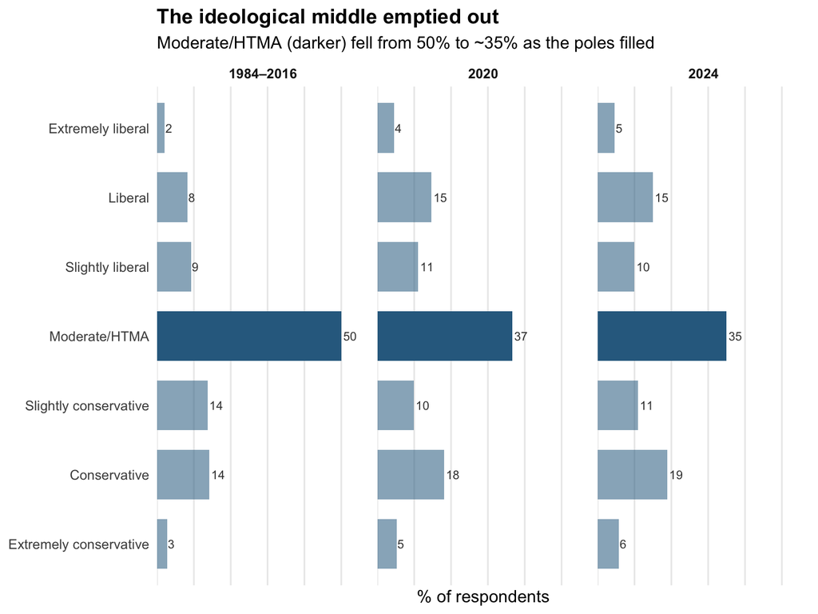

Figure 1: The ideological middle shrank as the poles grew. Seven-category liberal–conservative self-placement across three eras; the Moderate/HTMA category fell from 50% to about 35%. 1984–2016 is the reproduced ANES distribution; 2020/2024 are the replication distributions.

```r
eras <- bind_rows(
  R_fig1$ideology     |> transmute(cat = ideo_cat, label, pct, era = "1984–2016"),
  X_fig1$y2020$ideology |> transmute(cat = ideo_cat, label, pct, era = "2020"),
  X_fig1$y2024$ideology |> transmute(cat = ideo_cat, label, pct, era = "2024")
) |>
  mutate(label = factor(label, levels = R_fig1$ideology$label),
         era = factor(era, levels = c("1984–2016","2020","2024")),
         is_mid = label == "Moderate/HTMA")

ggplot(eras, aes(x = pct, y = forcats::fct_rev(label))) +
  geom_col(aes(alpha = is_mid), fill = "#2f6b8f", width = 0.72) +
  geom_text(aes(label = sprintf("%.0f", pct)), hjust = -0.15, size = 3, colour = "grey25") +
  scale_alpha_manual(values = c(`TRUE` = 1, `FALSE` = 0.55), guide = "none") +
  scale_x_continuous(expand = expansion(mult = c(0, 0.15))) +
  facet_wrap(~era) +
  labs(x = "% of respondents", y = NULL,
       title = "The ideological middle emptied out",
       subtitle = "Moderate/HTMA (darker) fell from 50% to ~35% as the poles filled") +
  theme_minimal(base_size = 12) +
  theme(panel.grid.major.y = element_blank(),
        panel.grid.minor = element_blank(),
        axis.text.x = element_blank(),
        plot.title = element_text(face = "bold"),
        strip.text = element_text(face = "bold"))
```

**Full replication grids (correlations, reliability, vote, by knowledge group)**

```r
X_t4$table4_2020 |>
  mutate(across(Full:Highest, ~round(.x,2))) |> select(-N) |>
  gt() |> tab_header(title = "2020 correlations by knowledge group")
```

Table 14: Replication Table 4 analogue (2020): construct correlations by quiz-knowledge group.

2020 correlations by knowledge group

| pair | Full | Lowest | Low | Middle | High | Highest |
| --- | --- | --- | --- | --- | --- | --- |
| Egal x MoralTrad(rev) | 0.44 | 0.30 | 0.28 | 0.44 | 0.50 | 0.56 |
| Egal x Policy | 0.62 | 0.53 | 0.48 | 0.62 | 0.67 | 0.71 |
| Egal x IdeoID(rev) | 0.55 | 0.45 | 0.33 | 0.56 | 0.61 | 0.66 |
| Egal x Party(rev) | 0.55 | 0.49 | 0.41 | 0.53 | 0.61 | 0.65 |
| MoralTrad x Policy(rev) | 0.59 | 0.43 | 0.45 | 0.59 | 0.63 | 0.68 |
| MoralTrad x IdeoID | 0.59 | 0.46 | 0.46 | 0.59 | 0.63 | 0.69 |
| MoralTrad x Party | 0.50 | 0.34 | 0.36 | 0.51 | 0.56 | 0.62 |
| Policy x IdeoID(rev) | 0.71 | 0.59 | 0.53 | 0.68 | 0.78 | 0.84 |
| Policy x Party(rev) | 0.67 | 0.61 | 0.53 | 0.65 | 0.71 | 0.76 |
| IdeoID x Party | 0.70 | 0.58 | 0.55 | 0.67 | 0.78 | 0.81 |

```r
X_t5$table5_2020 |>
  mutate(across(Full:Highest, ~round(.x,2))) |> select(-H_div_L_R2) |>
  gt() |> tab_header(title = "2020 vote probit coefficient / SE / pseudo-R²")
```

Table 15: Replication Table 5 analogue (2020): vote probit by merged voter knowledge group.

2020 vote probit coefficient / SE / pseudo-R²

| predictor | N | stat | Full | Lower | Middle | High | Highest |
| --- | --- | --- | --- | --- | --- | --- | --- |
| Egalitarianism | 6049 | coef | 2.18 | 1.84 | 2.04 | 2.41 | 2.83 |
| Egalitarianism | 6049 | se | 0.07 | 0.12 | 0.12 | 0.12 | 0.18 |
| Egalitarianism | 6049 | pseudoR2 | 0.31 | 0.24 | 0.28 | 0.35 | 0.47 |
| Moral Tradition | 6042 | coef | 1.69 | 1.30 | 1.71 | 1.83 | 2.34 |
| Moral Tradition | 6042 | se | 0.06 | 0.10 | 0.12 | 0.09 | 0.17 |
| Moral Tradition | 6042 | pseudoR2 | 0.29 | 0.16 | 0.28 | 0.34 | 0.47 |
| Policy Views | 6073 | coef | 3.10 | 2.50 | 3.10 | 3.48 | 4.18 |
| Policy Views | 6073 | se | 0.12 | 0.22 | 0.21 | 0.24 | 0.42 |
| Policy Views | 6073 | pseudoR2 | 0.46 | 0.31 | 0.45 | 0.52 | 0.67 |
| Ideology ID | 6070 | coef | 2.52 | 1.91 | 2.48 | 3.11 | 3.31 |
| Ideology ID | 6070 | se | 0.10 | 0.17 | 0.18 | 0.19 | 0.26 |
| Ideology ID | 6070 | pseudoR2 | 0.42 | 0.25 | 0.40 | 0.53 | 0.62 |
| Partisanship | 6064 | coef | 2.05 | 1.97 | 1.93 | 2.18 | 2.38 |
| Partisanship | 6064 | se | 0.07 | 0.13 | 0.11 | 0.15 | 0.19 |
| Partisanship | 6064 | pseudoR2 | 0.59 | 0.57 | 0.55 | 0.64 | 0.64 |

### 5.7 Verdicts

Set against the four original headline claims, the picture is consistent across metrics (Table 16): the descriptive portrait shifted while the underlying knowledge mechanism persisted in weakened form.

```r
verd <- tibble::tibble(
  `Original claim` = c(
    "1. Polar/coherent/potent ideology only for the knowledgeable ~20–30%",
    "2. Partisanship dominates ideology on every metric",
    "3. Knowledge stratification is enormous (info-gain 1.6–11×)",
    "4. Values carry the same knowledge-dependent limits as ideology"),
  `Verdict in 2020/2024` = c(
    "Not replicated as stated. The knowledge gradient persists, but the low-knowledge floor rose enough that ideology is no longer confined to a minority, though net of party the independent rise is small.",
    "Replicated, though the gap narrowed.",
    "Splits by metric. Breadth is roughly unchanged, having always been modest on a quiz, while vote potency is sharply reduced but not eliminated.",
    "Replicated structurally. Values track ideology: all rise, and all flatten."),
  `Key evidence` = c(
    "Lowest-K ideology vote-R² .04→.25/.31; ideology×party corr lowest group .06→.59",
    "Party÷ideology vote-R² 2.1×→1.4×; ideology stability .37→.64 nears party's .78",
    "Vote-R² H÷L quiz ideology 10.5→~2.5/2.0; breadth H÷L quiz ideology 2.29→1.9",
    "Avg corr egal .36→.54, MT .31→.53, parallel to ideology .39→.64")
)
verd |>
  gt() |>
  tab_header(title = "Two-sided result: the portrait is time-bound, the mechanism partly persists") |>
  cols_align("left", columns = everything())
```

Table 16: The four original headline claims in 2020/2024.

Two-sided result: the portrait is time-bound, the mechanism partly persists

[output not shown]

## 6 GSS Conceptual Replication

The GSS test asks whether the pattern recurs in a *different survey* with a *different knowledge proxy* (WORDSUM vocabulary), addressing the nomination’s cross-dataset priority. The result is an instructive **depth-versus-breadth dissociation**. The depth gradients replicate almost identically. The ideology×party correlation rises from 0.10 in the lowest WORDSUM group to 0.71 in the highest (full-sample 0.44), tracking Kalmoe’s ANES interviewer-rating gradient of .06→.68 almost exactly. Policy-index reliability rises 0.65→0.86, and ideology’s vote pseudo-R² is about 15× larger at the top (0.45) than the bottom (0.03). Partisanship dominates ideology in *every* knowledge group with a comfortable margin: its vote pseudo-R² runs 0.34 (lowest) to 0.59 (highest), against ideology’s 0.03 and 0.45. Even in the top group, where ideology is strongest, partisanship leads by 0.14. This “every group” claim is a within-group comparison, not the full-sample partisanship value set against the top-group ideology value.

The **breadth** gradient, by contrast, does not replicate: the ideology polar-half ratio is only 1.29 with WORDSUM, and 1.40 with education, against Kalmoe’s 4.0. The explanation is not a weak moderator, because the *same* WORDSUM bins produce a clean 7× correlation gradient and a 15× vote-potency gradient, so verbal ability tracks the depth metrics faithfully. What differs is the metric. GSS POLVIEWS offers no “haven’t thought much” escape, and so forces a substantive 7-point placement, with only 3.4% declining to place. Since RC2 showed the ANES breadth gradient is largely a nonresponse gradient, removing the nonresponse channel is exactly what should flatten it: low-knowledge respondents choose polar *labels* almost as often as sophisticates once they cannot opt out, but only among the knowledgeable do those labels cohere with party, policy, and the vote. Because breadth is primarily a nonresponse artefact, the strength of the knowledge proxy is beside the point for it; the proxy’s strength is instead what lets it reproduce the depth gradients, which it does. The deeper and more consequential half of the thesis replicates cleanly across the dataset boundary.

The GSS also shows the two-sided temporal story in one dataset. Full-sample ideology×party constraint tripled from the 1970s (.21) to the 2020s (.64), the well-documented partisan sort (Levendusky 2009; Mason 2018), yet the knowledge gap persists in every decade: even in the 2020s the bottom-knowledge correlation (.30) sits far below the top’s (.77). Sorting raised the average without erasing stratification, so an unstratified 2020s snapshot still overstates ideological constraint for most citizens.

## 7 Discussion

**What the original got right: nearly everything, reproducibly so.** The reproduction regenerates the published tables cell by cell from the same public data, and every substantive conclusion survives a demanding robustness suite that validates against the author’s own supplement. The three anomalies are documentation-level: a probable N transposition, one unreproducible panel cell, and one undocumented panel item set. For a secondary-data paper with no code package, this is an unusually clean bill of health, and it should raise rather than lower confidence in the original analysis.

**Implications for the four best practices.** All four survive. Stratifying by knowledge still matters, since the gradient is compressed rather than gone, and an unstratified estimate still misleads. Convenience samples still over-represent the knowledgeable (Clifford, Jewell, and Waggoner 2015). Distinguishing ideology from partisanship matters more than ever: the two are now highly correlated, partisanship still leads on every metric, and conflating them risks attributing to ideology what party identity produces, as the party-controlled analysis above shows concretely. And full-sample estimates remain knowledge-conditioned. To these I would add three refinements that this project surfaces: **report how nonattitudes are handled**, since the breadth statistic is partly a nonresponse statistic (RC2, GSS); **prefer marginal effects to pseudo-R² ratios** when describing how strongly a predictor stratifies, since the two can differ by an order of magnitude (RC6c); and **beware that a knowledge quiz and an interviewer rating are not interchangeable stratifiers**, since the quiz yields systematically shallower gradients, so cross-era comparisons must be measure-matched.

**Limitations.** Several constraints bound these conclusions. The replication’s knowledge measure is a quiz rather than the interviewer rating (handled by the quiz-versus-quiz benchmark, though a residual instrument difference remains); 2020 and 2024 are single elections compared against multi-year pools (which can inflate the apparent jump, though the 2008–2016 pool bounds this); the mode shifted to web without an interviewer to probe nonresponse (its effect on HTMA/DK is modest but not separable from the era); the value batteries are reduced (handled via matched items and covariance); the analysis is single-country except for the GSS; and two panel rows are reconstructions rather than exact reproductions. The headline ratios are also imprecise, since they divide two pseudo-R² values estimated in subsamples. A nonparametric bootstrap of the 2020 ideology Highest÷Lower vote-potency ratio (500 draws; Lower $n = 1,477$, Highest $n = 1,126$) puts the point estimate 2.49 in a 95% interval of 2.00–3.19, well below the original era’s ~10× but too wide to distinguish the 2020 ratio sharply from the 2024 one. The ratios should therefore be read as order-of-magnitude compressions rather than precise point estimates. None of these undoes the direction or rough magnitude of the results, all of which were independently verified.

## 8 Reproducibility Statement

```
Rscript R/01_prepare_cdf.R        # ANES CDF → cdf_analysis.rds
Rscript R/02_reproduce_main.R     # Tables 1,2,4,5, Fig 1, footnote 5, in-text
Rscript R/03_robustness.R         # RC1–RC8
Rscript R/04_panels.R             # Table 3 (panels)
Rscript R/05_gss.R                # GSS conceptual replication
Rscript R/06_replication_anes.R   # ANES 2020/2024 + panel
Rscript R/07_revision.R           # post-review analyses → output/revision/*.rds
# Independent verification pass (§2.4): hand-rolled recomputation of every headline
Rscript output/verification/v_reproduction.R
Rscript output/verification/v_robustness.R
Rscript output/verification/v_panels.R
Rscript output/verification/v_replication.R
Rscript output/verification/v_gss.R
quarto render manuscript/manuscript.qmd
```

Data sources: ANES Cumulative Data File (1948–2016 vintage via the `anesr` mirror; 1948–2024 subset via SDA Berkeley, accessed 2026-07-03), the ANES 1990–92 / 1992–96 / 2000–02 panels, the 2024 knowledge battery and 2016–20–24 panel link (SDA), and the GSS 1972–2024 Cumulative Datafile (SDA). This manuscript reads only the precomputed `.rds` outputs, so it renders quickly and independently of the analysis scripts. Repository layout: `R/` (numbered pipeline), `data/raw/` (downloaded subsets), `output/` (per-module `.rds`, `comparison.csv`, and reports), `notes/` (decisions log and data provenance), `manuscript/` (this document and `references.bib`). No original code or data package exists for Kalmoe (2020); the pipeline reconstructs the analysis from the paper and its author-hosted online supplement.

## Workflow and AI-Assistance Statement

This manuscript was subsequently revised in response to an automated peer review generated by a “coarse” review pipeline (a structured, multi-stage critique run with a local model). The full review is archived at `coarse-output/manuscript_review.md`. In response, six new analyses were added — the party-controlled (“sorting versus constraint”) vote models, AME-based stratification ratios, panel attrition and reweighting, breadth with and without nonattitudes, a within-2020 mode comparison, and a set of smaller checks — all in `R/07_revision.R` (outputs in `output/revision/`), and the interpretive claims were tightened accordingly. The revision changed one headline emphasis on the evidence: the party-controlled test showed that ideology’s independent vote contribution did not rise, so the “time-bound” reading is now qualified as substantially an ideology–party alignment shift.

## References

American National Election Studies. 2021. “ANES 2020 Time Series Study Full Release [Dataset and Documentation].” July 19, 2021 version. https://www.electionstudies.org.

———. 2025. “ANES 2024 Time Series Study Full Release [Dataset and Documentation].” August 8, 2025 version. https://www.electionstudies.org.

———. 2026. “ANES Time Series Cumulative Data File [Dataset and Documentation].” February 5, 2026 version. https://www.electionstudies.org.

Barber, Michael, and Jeremy C. Pope. 2019. “Does Party Trump Ideology? Disentangling Party and Ideology in America.” *American Political Science Review* 113 (1): 38–54. https://doi.org/10.1017/s0003055418000795.

Clifford, Scott, Ryan M. Jewell, and Philip D. Waggoner. 2015. “Are Samples Drawn from Mechanical Turk Valid for Research on Political Ideology?” *Research & Politics* 2 (4). https://doi.org/10.1177/2053168015622072.

Converse, Philip E. 1964. “The Nature of Belief Systems in Mass Publics.” In *Ideology and Discontent*, edited by David E. Apter, 206–61. New York: The Free Press.

Davern, Michael, Rene Bautista, Jeremy Freese, Pamela Herd, and Stephen L. Morgan. 2026. “General Social Survey 1972-2024 [Machine-Readable Data File].” Chicago: NORC ed. 1 datafile (Release 3) and 1 codebook (2024 Release 3).

FORRT. 2026. “ReplicaTHIS Nomination #8.” https://forrt.org/replicatethis/nomination/8/.

Freese, Jeremy, and David Peterson. 2017. “Replication in Social Science.” *Annual Review of Sociology* 43: 147–65. https://doi.org/10.1146/annurev-soc-060116-053450.

Jost, John T. 2006. “The End of the End of Ideology.” *American Psychologist* 61 (7): 651–70. https://doi.org/10.1037/0003-066x.61.7.651.

Kalmoe, Nathan P. 2020. “Uses and Abuses of Ideology in Political Psychology.” *Political Psychology* 41 (4): 771–93. https://doi.org/10.1111/pops.12650.

Kinder, Donald R., and Nathan P. Kalmoe. 2017. *Neither Liberal nor Conservative: Ideological Innocence in the American Public*. Chicago: University of Chicago Press. https://doi.org/10.7208/chicago/9780226452593.001.0001.

Levendusky, Matthew. 2009. *The Partisan Sort: How Liberals Became Democrats and Conservatives Became Republicans*. Chicago: University of Chicago Press. https://doi.org/10.7208/chicago/9780226473673.001.0001.

Mason, Lilliana. 2018. *Uncivil Agreement: How Politics Became Our Identity*. Chicago: University of Chicago Press. https://doi.org/10.7208/chicago/9780226524689.001.0001.

R Core Team. 2026. *R: A Language and Environment for Statistical Computing*. Vienna, Austria: R Foundation for Statistical Computing. https://www.R-project.org/.

Revelle, William. 2026. *Psych: Procedures for Psychological, Psychometric, and Personality Research*. Evanston, Illinois: Northwestern University. https://CRAN.R-project.org/package=psych.

Zeileis, Achim, Susanne Köll, and Nathaniel Graham. 2020. “Various Versatile Variances: An Object-Oriented Implementation of Clustered Covariances in R.” *Journal of Statistical Software* 95 (1): 1–36. https://doi.org/10.18637/jss.v095.i01.